# RandomForest

Christopher Aldama Pérez

8 de mayo de 2016

## Barbell Lifts and Ramdom Forest

This document is a submission to the Practical Machine Learning Assigment, as part of the Coursera DataScience specialization. The task is to fit a model that can predict the type of excersice performed using accelerometer data from fit bands.

### Loading the data set and preprocessing

```r
library(caret)
set.seed(12345)
training.csv <- read.csv('pml-training.csv')
testing <- read.csv('pml-testing.csv')
trainIdx <- createDataPartition(training.csv$classe, p = 0.75, list = F)
training <- training.csv[trainIdx, ]
validation <- training.csv[-trainIdx, ]
```

Exploring the names of the training columns reveals that some columns contains descriptive text that it’s not relevant to the model. Another way to filter useless columns it’s using the nearZeroVar function that helps to identify predictors with almost no variance and remove columns with lots of NA or empty values.

```r
zero <- nearZeroVar(training)
training <- training[, -zero]
desc <- c("X", "user_name", "raw_timestamp_part_1", "raw_timestamp_part_2",
"cvtd_timestamp", "new_window", "num_window")
training <- training[, !names(training) %in% desc]

count <- sapply(training, function(x) {
  sum(!(is.na(x) | x == ""))
})
nullcol <- names(count[count < 0.6 * length(training$classe)])
training <- training[, !names(training) %in% c(nullcol)]
```

### Model Fitting

In order to create the model, we can use the train function provided by the caret library and the “rf” method to use Random Forest, this can take some time to compute.

```r
model.rf <- train(classe ~ ., data=training, method='rf')
```

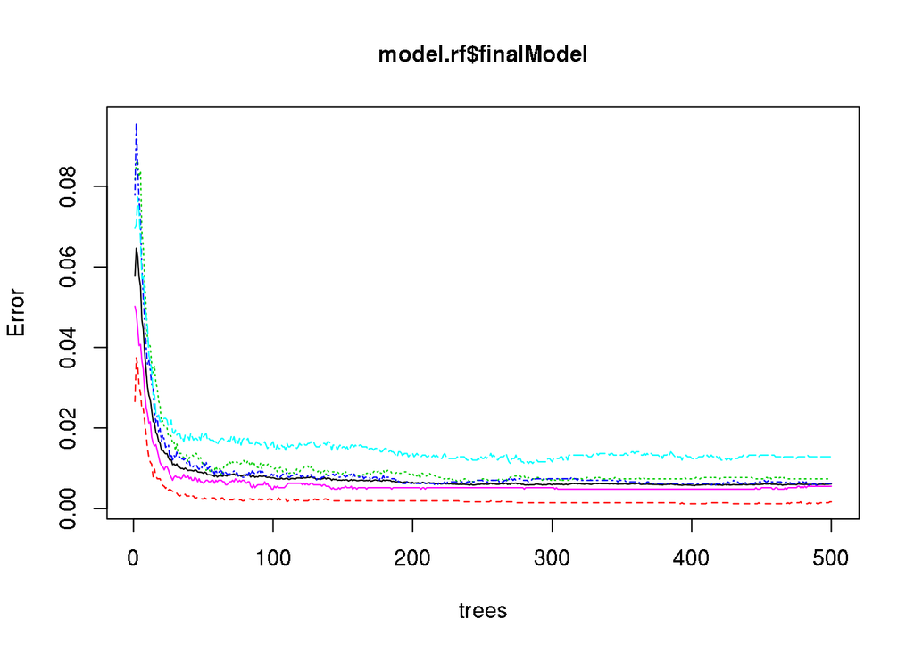

```r
plot(model.rf$finalModel)
```

### Cross Validation

Now we can use the validation dataset to test our model prediction Accuracy

```r
pred.rf <- predict(model.rf, validation)
print(confusionMatrix(pred.rf, validation$classe)$overall)
```

```
##       Accuracy          Kappa  AccuracyLower  AccuracyUpper   AccuracyNull
##      0.9928630      0.9909720      0.9900880      0.9950239      0.2844617
## AccuracyPValue  McnemarPValue
##      0.0000000            NaN
```

We can see that the Accuracy is really good.

### Prediction

The final step is to predict the outcome of new data, in thi case the outcome of the testing dataset

```r
 pred.test.rf <- predict(model.rf, testing)
 print(pred.test.rf)
```

```
##  [1] B A B A A E D B A A B C B A E E A B B B
## Levels: A B C D E
```